# Homework 4

Huang Sisi

## Chapter 8

3. Consider the Gini index, classification error, and entropy in a simple classification setting with two classes. Create a single plot that displays each of these quantities as a function of $\hat{p}_{m 1}$. The $x$ axis should display $\hat{p}_{m 1}$, ranging from 0 to 1, and the $y$ -axis should display the value of the Gini index, classification error, and entropy.

*Answer*. Gini index:

$$\begin{equation}
G_m = \sum_{k=1}^K\hat{p}_{m k}(1-\hat{p}_{m k}).
\end{equation}$$

Classification error:

$$\begin{equation}
C_m = 1-max\{\hat{p}_{m k}\}.
\end{equation}$$

Cross entropy:

$$\begin{equation}
D_{m}=-\sum_{k=1}^{K} \hat{p}_{m k} \log \hat{p}_{m k}.
\end{equation}$$

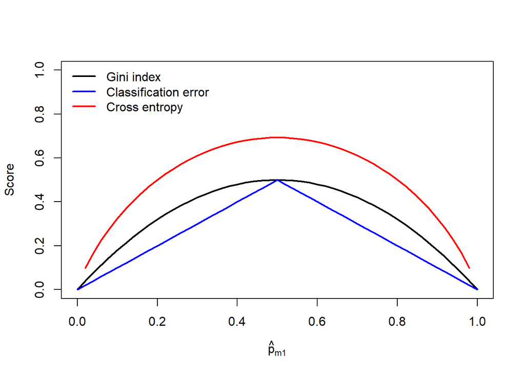

```r
p = seq(0,1,0.02)
G = 2*p*(1-p)
C = 1-pmax(p,1-p)
D = -(p*log(p)+(1-p)*log(1-p))
plot(p, G, type = "l", ylim = c(0,1), lwd=2,
     xlab = TeX('$\\hat{p}_{m 1}$'), ylab = "Score")
lines(p, C, type = "l", col = 'blue', lwd=2)
lines(p, D, type = "l", col = 'red', lwd=2)
legend(x='topleft', legend=c('Gini index','Classification error','Cross entropy'),
       col=c('black','blue','red'), lty=1, lwd=2, bty="n")
```

4. This question relates to the plots in Figure $8.12$.

1. Sketch the tree corresponding to the partition of the predictor space illustrated in the left-hand panel of Figure 8.12. The numbers inside the boxes indicate the mean of $Y$ within each region.

```
                  X1<1
                 ___|___
                |       |
              X2<1      5
             ___|___
            |       |
          X1<0      15
         ___|___
        |       |
        3     X2<0
             ___|___
            |       |
            10      0
```

2. Create a diagram similar to the left-hand panel of Figure $8.12$, using the tree illustrated in the right-hand panel of the same figure. You should divide up the predictor space into the correct regions, and indicate the mean for each region.

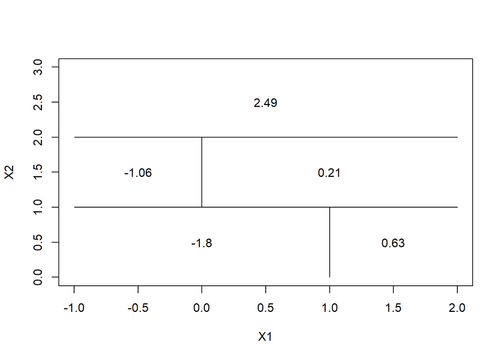

```r
plot(NA, NA, xlim = c(-1, 2), ylim = c(0, 3), xlab = "X1", ylab = "X2")
lines(x = c(-1, 2), y = c(1, 1))
lines(x = c(1, 1), y = c(0, 1))
lines(x = c(-1, 2), y = c(2, 2))
lines(x = c(0, 0), y = c(1, 2))
text(x = 0, y = 0.5, labels = '-1.8')
text(x = 1.5, y = 0.5, labels = '0.63')
text(x = -0.5, y = 1.5, labels = '-1.06')
text(x = 1, y = 1.5, labels = '0.21')
text(x = 0.5, y = 2.5, labels = '2.49')
```

7. In the lab, we applied random forests to the `Boston` data using `mtry=6` and using `ntree=25` and `ntree=500`. Create a plot displaying the test error resulting from random forests on this data set for a more combrehensive range of values for `mtry` and `ntree`. You can model your plot after Figure 8.10. Describe the results obtained.

```r
library(MASS)
library(randomForest)
```

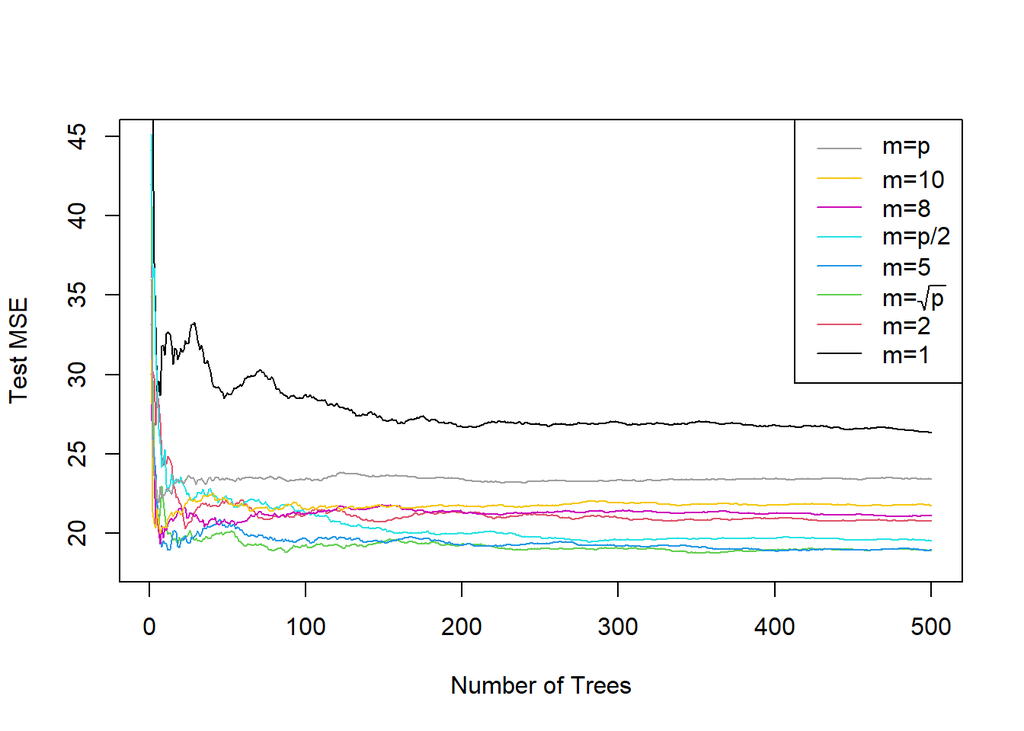

```r
set.seed(1)
train = sample(nrow(Boston), nrow(Boston)/2)
X.train = Boston[train, -ncol(Boston)]
X.test = Boston[-train, -ncol(Boston)]
Y.train = Boston[train, ncol(Boston)]
Y.test = Boston[-train, ncol(Boston)]

p = ncol(Boston) - 1 # 13
p.2 = p/2 # 6.5
p.sq = sqrt(p) # 3.6
p1 = 1
p2 = 2
p3 = 5
p4 = 8
p5 = 10
p.vec <- c(1,2,sqrt(p),5,p/2,8,10,p)

plot(NA, NA, xlim = c(1,500), ylim = c(18,45), xlab = "Number of Trees", ylab = "Test MSE")
for (i in 1:length(p.vec)) {
  set.seed(3)
  rf = randomForest(X.train, Y.train, X.test, Y.test, mtry = p.vec[i], ntree = 500)
  lines(1:500, rf$test$mse, col = i, type = "l")
}

legend("topright", c("m=p","m=10","m=8","m=p/2","m=5", TeX('$m=\\sqrt{p}$'),"m=2","m=1"),
       col = rev(1:length(p.vec)), cex = 1, lty = 1)
```

Results: `mtry` around $\sqrt{p}$ is the best. The MSE reduces as we add more trees and becomes stable when the number of trees is over 100.

8. In the lab, a classification tree was applied to the `Carseats` data set after converting `Sales` into a qualitative response variable. Now we will seek to predict `Sales` using regression trees and related approaches, treating the response as a quantitative variable.

1. Split the data set into a training set and a test set.

```r
library(ISLR)
set.seed(1)
train=sample(nrow(Carseats),nrow(Carseats)/2)
XY.train = Carseats[train, ]
XY.test = Carseats[-train, ]
```

2. Fit a regression tree to the training set. Plot the tree, and interpret the results. What test MSE do you obtain?

```r
library(tree)
tree.carseats = tree(Sales ~ ., data = XY.train)
summary(tree.carseats)
```

```
##
## Regression tree:
## tree(formula = Sales ~ ., data = XY.train)
## Variables actually used in tree construction:
## [1] "ShelveLoc"   "Price"       "Age"         "Advertising" "CompPrice"
## [6] "US"
## Number of terminal nodes:  18
## Residual mean deviance:  2.167 = 394.3 / 182
## Distribution of residuals:
##     Min.  1st Qu.   Median     Mean  3rd Qu.     Max.
## -3.88200 -0.88200 -0.08712  0.00000  0.89590  4.09900
```

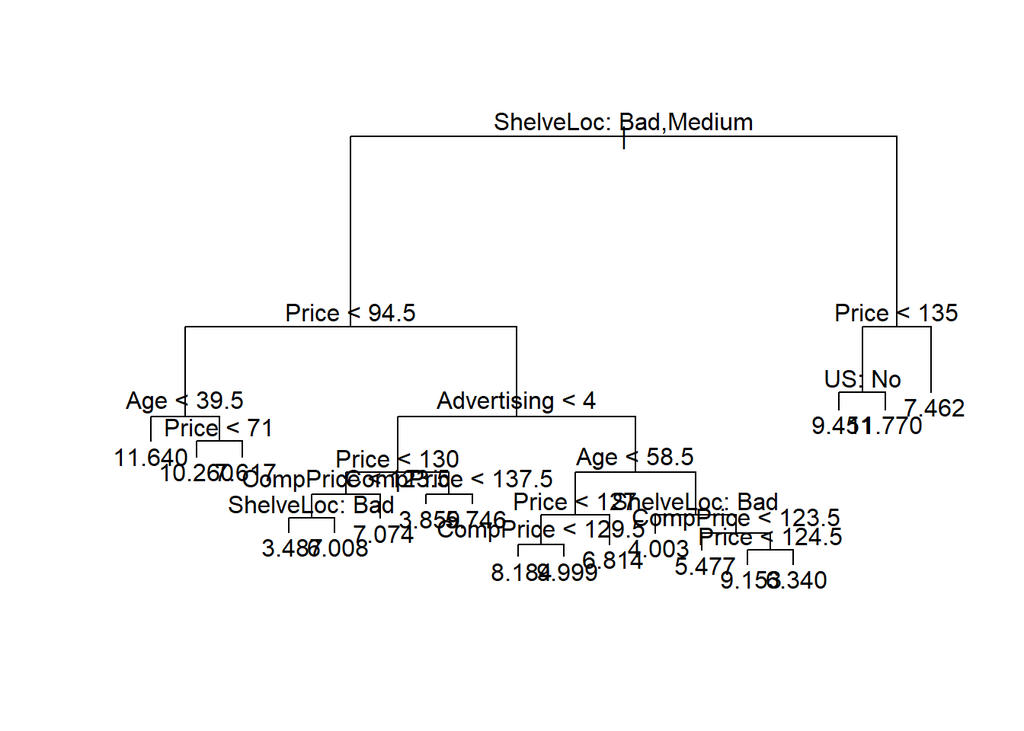

```r
plot(tree.carseats)
text(tree.carseats, pretty = 0)
```

The most important factors are `ShelveLoc` and `Price`. Variables actually used in tree construction are `ShelveLoc`, `Price`, `Age`, `Advertising`, `CompPrice` and `US`. There are 18 terminal nodes.

```r
tree.pred=predict(tree.carseats,Carseats[-train,])
mean((tree.pred-Carseats[-train,'Sales'])^2)
```

```
## [1] 4.922039
```

3. Use cross-validation in order to determine the optimal level of tree complexity. Does pruning the tree improve the test MSE?

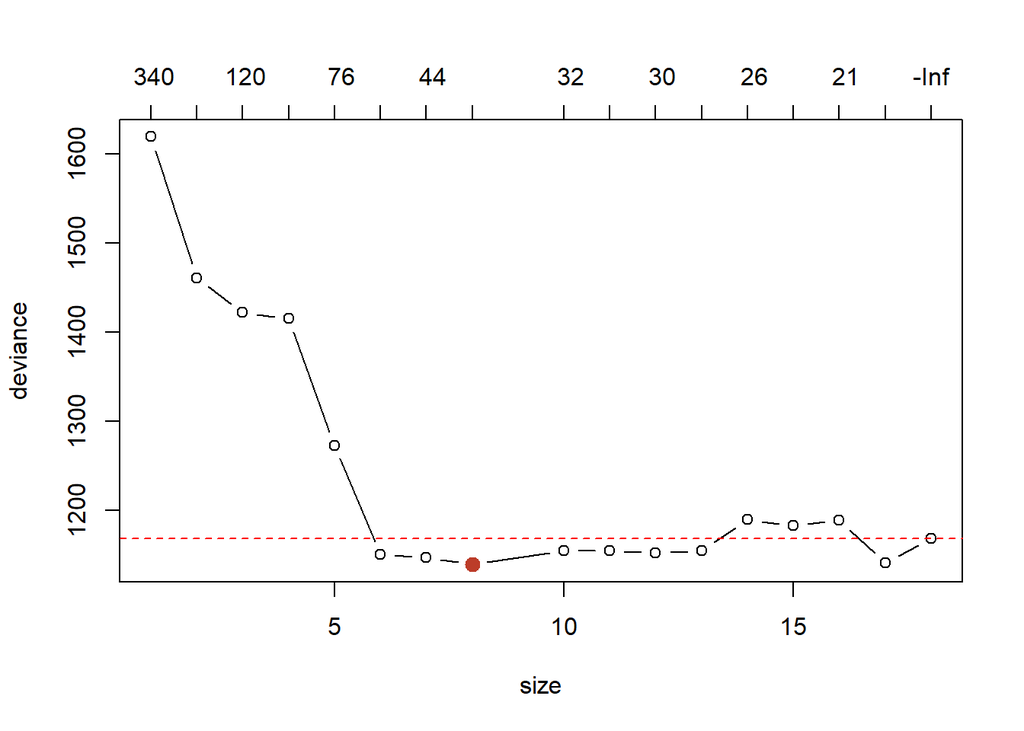

```r
set.seed(21)
cv.carseats=cv.tree(tree.carseats)
plot(cv.carseats, type = "b")
# Best size = 8
abline(h = min(cv.carseats$dev) + 0.2 * sd(cv.carseats$dev), col = "red", lty = 2)
points(cv.carseats$size[which.min(cv.carseats$dev)], min(cv.carseats$dev),
       col = "#BC3C29FF", cex = 2, pch = 20)
```

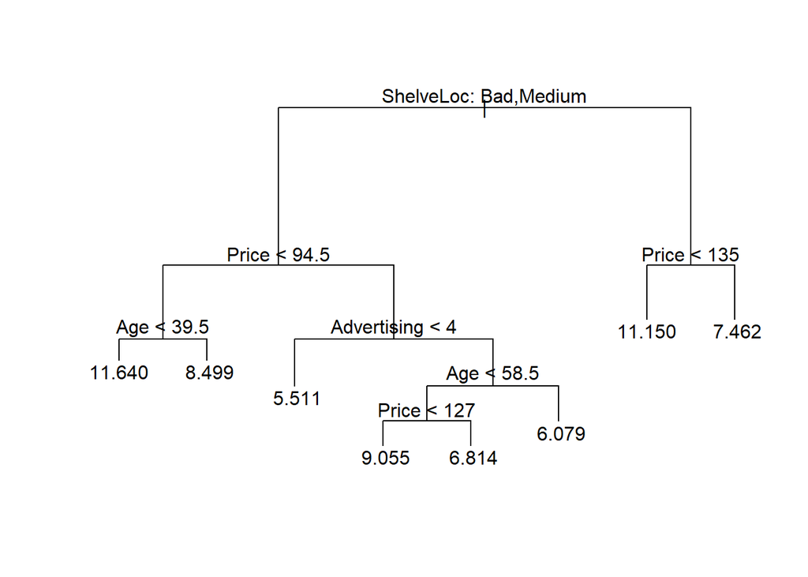

```r
prune.carseats = prune.tree(tree.carseats, best = 8)
plot(prune.carseats)
text(prune.carseats, pretty = 0)
```

```r
tree.pred=predict(prune.carseats,Carseats[-train,])
mean((tree.pred-Carseats[-train,'Sales'])^2)
```

```
## [1] 5.113254
```

In this case, pruning the tree increase the test MSE.

4. Use the bagging approach in order to analyze this data. What test MSE do you obtain? Use the `importance()` function to determine which variables are most important.

```r
# bagging approach: randomForest
p <- ncol(XY.train)-1
# here the effect of sqrt is worse
set.seed(21)
rf.carseats = randomForest(Sales ~ ., data = XY.train,
                            mtry = p, ntree = 500, importance = T)
rf.pred = predict(rf.carseats, XY.test)
mean((XY.test$Sales - rf.pred)^2)
```

```
## [1] 2.595496
```

The test MSE is 2.60.

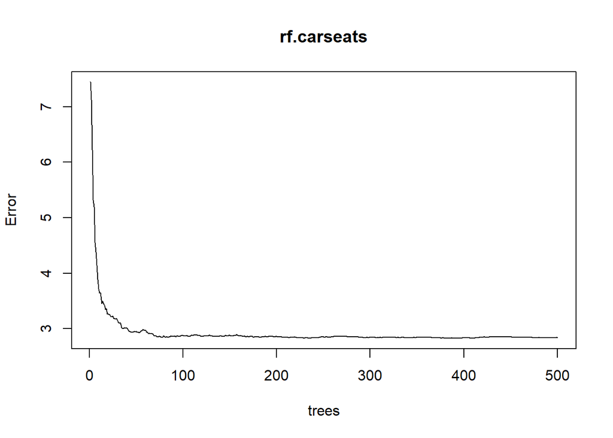

```r
plot(rf.carseats)
```

```r
importance(rf.carseats)
```

```
##                 %IncMSE IncNodePurity
## CompPrice   25.13520063    171.186481
## Income       5.55221834     87.922672
## Advertising 12.32147536    101.197188
## Population  -0.95340923     56.416532
## Price       57.20237322    505.817395
## ShelveLoc   50.09456001    378.046274
## Age         17.05122602    156.287849
## Education   -0.06614902     44.607234
## Urban        0.38147416      9.747216
## US           5.11200249     15.539388
```

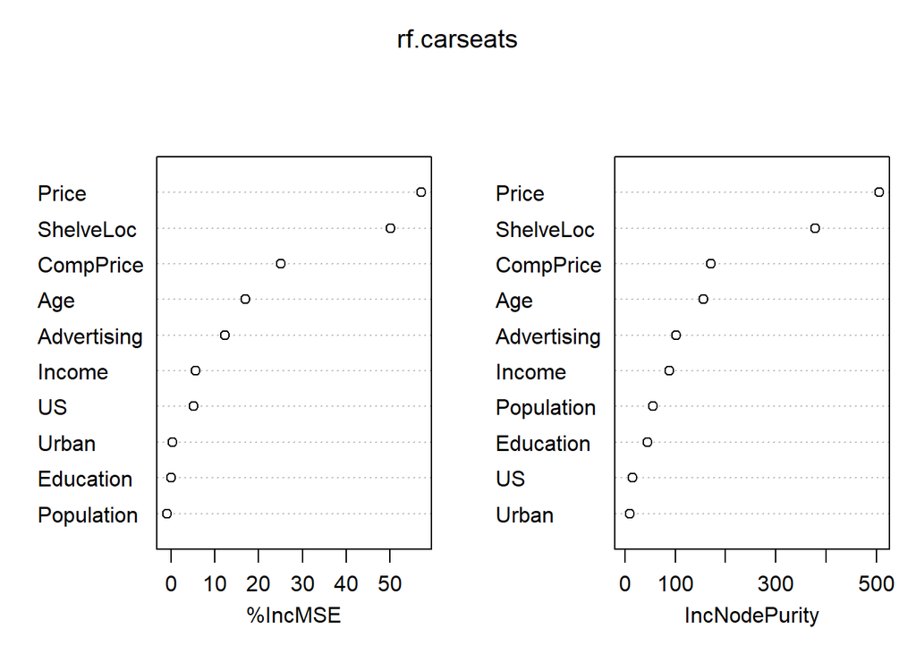

```r
varImpPlot(rf.carseats)
```

The most important variables to predict `Sales` are `Price` and `ShelveLoc`.

5. Use random forests to analyze this data. What test MSE do you obtain? Use the `importance()` function to determine which variables are most important. Describe the effect of $m$, the number of variables considered at each split, on the error rate obtained.

```r
set.seed(21)
rf.carseats = randomForest(Sales ~ ., data = XY.train,
                           mtry = sqrt(p), ntree = 500, importance = T)
rf.pred = predict(rf.carseats, XY.test)
mean((XY.test$Sales - rf.pred)^2)
```

```
## [1] 3.002791
```

In this case, `sqrt` works worse for mtry.

9. This problem involves the `OJ` data set which is part of the `ISLR` package.

1. Create a training set containing a random sample of 800 observations, and a test set containing the remaining observations.

```r
library(ISLR)
set.seed(10)

train = sample(nrow(OJ), 800)
OJ.train = OJ[train, ]
OJ.test = OJ[-train, ]
```

2. Fit a tree to the training data, with `Purchase` as the response and the other variables as predictors. Use the `summary()` function to produce summary statistics about the tree, and describe the results obtained. What is the training error rate? How many terminal nodes does the tree have?

```r
library(tree)
tree.OJ = tree(Purchase ~ ., data = OJ.train)
summary(tree.OJ)
```

```
##
## Classification tree:
## tree(formula = Purchase ~ ., data = OJ.train)
## Variables actually used in tree construction:
## [1] "LoyalCH"   "DiscMM"    "PriceDiff"
## Number of terminal nodes:  7
## Residual mean deviance:  0.7983 = 633 / 793
## Misclassification error rate: 0.1775 = 142 / 800
```

3. Type in the name of the tree object in order to get a detailed text output. Pick one of the terminal nodes, and interpret the information displayed.

```r
tree.OJ
```

```
## node), split, n, deviance, yval, (yprob)
##       * denotes terminal node
##
##  1) root 800 1067.000 CH ( 0.61375 0.38625 )
##    2) LoyalCH < 0.48285 290  315.900 MM ( 0.23448 0.76552 )
##      4) LoyalCH < 0.035047 51    9.844 MM ( 0.01961 0.98039 ) *
##      5) LoyalCH > 0.035047 239  283.600 MM ( 0.28033 0.71967 )
##       10) DiscMM < 0.47 220  270.500 MM ( 0.30455 0.69545 ) *
##       11) DiscMM > 0.47 19    0.000 MM ( 0.00000 1.00000 ) *
##    3) LoyalCH > 0.48285 510  466.000 CH ( 0.82941 0.17059 )
##      6) LoyalCH < 0.764572 245  300.200 CH ( 0.69796 0.30204 )
##       12) PriceDiff < 0.145 99  137.000 MM ( 0.47475 0.52525 )
##         24) DiscMM < 0.47 82  112.900 CH ( 0.54878 0.45122 ) *
##         25) DiscMM > 0.47 17   12.320 MM ( 0.11765 0.88235 ) *
##       13) PriceDiff > 0.145 146  123.800 CH ( 0.84932 0.15068 ) *
##      7) LoyalCH > 0.764572 265  103.700 CH ( 0.95094 0.04906 ) *
```

Pick the terminal node 7) as an example. There are 265 samples in the subtree below this node. The deviance for all samples below this node is 103.700. If `LoyalCH`>0.48 and `LoyalCH`>0.76, the prediction of `Purchase` by this node is CH because about 95.1% of samples take `Purchase` as CH.

4. Create a plot of the tree, and interpret the results.

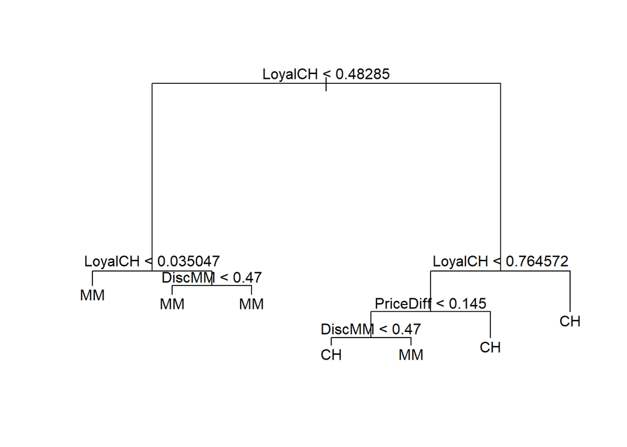

```r
plot(tree.OJ)
text(tree.OJ, pretty = 0)
```

The variable `LoyalCH` is the most decisive. If `LoyalCH`<0.48, the predictions are all MM (I do not know why the nodes are further divided. It may be due to the different prediction probabilities). And if `LoyalCH`>0.76, the prediction is CH. If `LoyalCH`<0.76, there are subtrees predicted by `PriceDiff` and `DiscMM`.

5. Predict the response on the test data, and produce a confusion matrix comparing the test labels to the predicted test labels. What is the test error rate?

```r
pred.OJ = predict(tree.OJ, OJ.test, type = "class")
table(OJ.test$Purchase, pred.OJ)
```

```
##     pred.OJ
##       CH  MM
##   CH 135  27
##   MM  20  88
```

6. Apply the `cv.tree()` function to the training set in order to determine the optimal tree size.

```r
set.seed(1)
cv.OJ = cv.tree(tree.OJ)
```

7. Produce a plot with tree size on the $x$ -axis and cross-validated classification error rate on the $y$ -axis.

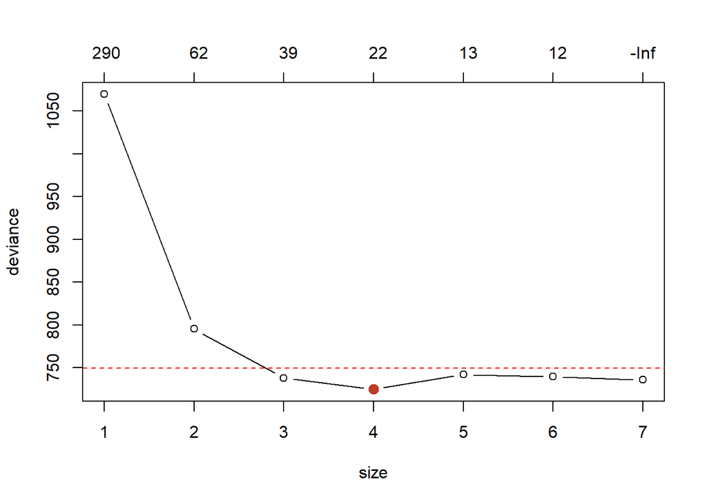

```r
plot(cv.OJ, type = "b")
abline(h = min(cv.OJ$dev) + 0.2 * sd(cv.OJ$dev), col = "red", lty = 2)
points(cv.OJ$size[which.min(cv.OJ$dev)], min(cv.OJ$dev),
       col = "#BC3C29FF", cex = 2, pch = 20)
```

8. Which tree size corresponds to the lowest cross-validated classification error rate?

```r
s <- cv.OJ$size[which.min(cv.OJ$dev)]
s
```

```
## [1] 4
```

The tree size 4 corresponds to the lowest cross-validated classification error rate.

1. Produce a pruned tree corresponding to the optimal tree size obtained using cross-validation. If cross-validation does not lead to selection of a pruned tree, then create a pruned tree with five terminal nodes.

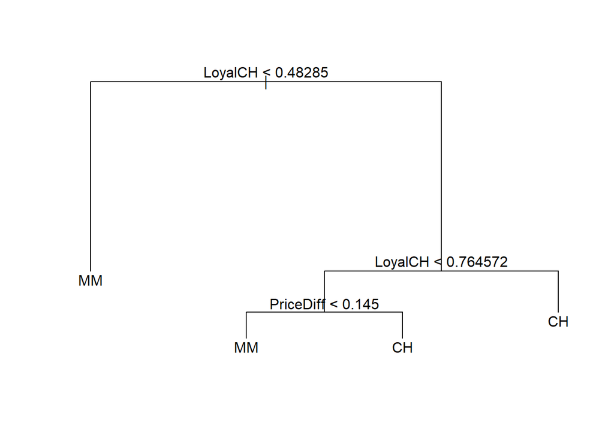

```r
prune.OJ = prune.tree(tree.OJ, best = s)
plot(prune.OJ)
text(prune.OJ, pretty = 0)
```

10. Compare the training error rates between the pruned and unpruned trees. Which is higher?

```r
summary(prune.OJ)
```

```
##
## Classification tree:
## snip.tree(tree = tree.OJ, nodes = c(12L, 2L))
## Variables actually used in tree construction:
## [1] "LoyalCH"   "PriceDiff"
## Number of terminal nodes:  4
## Residual mean deviance:  0.8548 = 680.4 / 796
## Misclassification error rate: 0.1875 = 150 / 800
```

The training error for pruned tree becomes higher.

11. Compare the test error rates between the pruned and unpruned trees. Which is higher?

```r
# Unpruned
# pred.OJ = predict(tree.OJ, OJ.test, type = "class")
sum(OJ.test$Purchase != pred.OJ)/length(pred.OJ)
```

```
## [1] 0.1740741
```

```r
# Pruned
pred.prune.OJ = predict(prune.OJ, OJ.test, type = "class")
sum(OJ.test$Purchase != pred.prune.OJ)/length(pred.OJ)
```

```
## [1] 0.1851852
```

In this case the error rate for pruned tree is also higher.

10. We now use boosting to predict `Salary` in the `Hitters` data set.

1. Remove the observations for whom the salary information is unknown, and then log-transform the salaries.

```r
hitters <- Hitters
hitters = hitters[-which(is.na(hitters$Salary)), ]
hitters$Salary = log(hitters$Salary)
```

2. Create a training set consisting of the first 200 observations, and a test set consisting of the remaining observations.

```r
train.hitters = hitters[1:200,]
test.hitters = hitters[-c(1:200),]
```

3. Perform boosting on the training set with 1,000 trees for a range of values of the shrinkage parameter $\lambda$. Produce a plot with different shrinkage values on the $x$-axis and the corresponding training set MSE on the $y$-axis.

```r
library(gbm)
lambdas <- 10^seq(-10, -0.2, by = 0.1)
err.train <- {}
err.test <- {}
for (lambda in lambdas) {
  boost.hitters <- gbm(Salary ~ ., data = train.hitters, distribution = "gaussian",
                       n.trees = 1000, shrinkage = lambda)
  pred.hitters.train <- predict(boost.hitters, train.hitters, n.trees = 1000)
  pred.hitters.test <- predict(boost.hitters, test.hitters, n.trees = 1000)
  err.train <- c(err.train, mean((train.hitters$Salary-pred.hitters.train)^2))
  err.test <- c(err.test, mean((test.hitters$Salary-pred.hitters.test)^2))
}
```

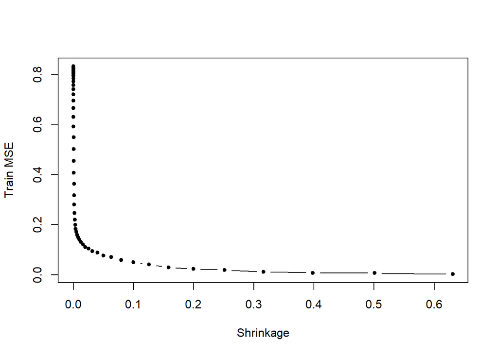

```r
plot(lambdas, err.train, type = "b", xlab = "Shrinkage", ylab = "Train MSE", pch = 20)
```

4. Produce a plot with different shrinkage values on the $x$-axis and the corresponding test set MSE on the $y$-axis.

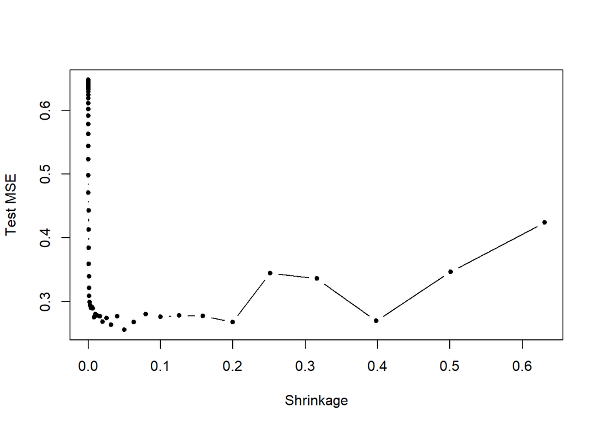

```r
plot(lambdas, err.test, type = "b", xlab = "Shrinkage", ylab = "Test MSE", pch = 20)
```

5. Compare the test MSE of boosting to the test MSE that results from applying two of the regression approaches seen in Chapters 3 and 6 .
- Test MSE of boosting

```r
lambdas[which.min(err.test)]
```

```
## [1] 0.05011872
```

```r
min(err.test)
```

```
## [1] 0.2556809
```

- Test MSE of linear regression

```r
lm.hitters = lm(Salary ~ ., data = train.hitters)
lm.pred = predict(lm.hitters, test.hitters)
mean((test.hitters$Salary - lm.pred)^2)
```

```
## [1] 0.4917959
```

- Test MSE of $L^2$ Regularization

`glmnet` solves the problem
$$\begin{equation}
\min _{\beta_{0}, \beta} \frac{1}{N} \sum_{i=1}^{N} w_{i} l\left(y_{i}, \beta_{0}+\beta^{T} x_{i}\right)+\lambda\left[(1-\alpha)\|\beta\|_{2}^{2} / 2+\alpha\|\beta\|_{1}\right]
\end{equation}$$

```r
library(glmnet)
x = model.matrix(Salary ~ ., data = train.hitters)
x.test = model.matrix(Salary ~ ., data = test.hitters)
lasso.hitters = glmnet(x, train.hitters$Salary, alpha = 0, lambda = 0.05)
lasso.pred = predict(lasso.hitters, s=0.05, newx = x.test)
mean((test.hitters$Salary - lasso.pred)^2)
```

```
## [1] 0.4572697
```

We can see the test MSE of boosting is the minimum, compared to the approach of linear regression and simple regularization.

6. Which variables appear to be the most important predictors in the boosted model?

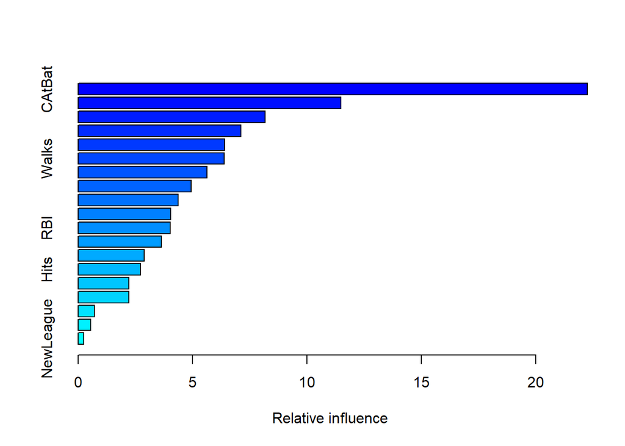

```
##                 var    rel.inf
## CAtBat       CAtBat 22.2442320
## CRuns         CRuns 11.4754960
## CWalks       CWalks  8.1730869
## PutOuts     PutOuts  7.1059798
## Years         Years  6.3929361
## Walks         Walks  6.3792319
## CHmRun       CHmRun  5.6313253
## CHits         CHits  4.9418480
## AtBat         AtBat  4.3655210
## Assists     Assists  4.0491887
## RBI             RBI  4.0191254
## CRBI           CRBI  3.6315083
## HmRun         HmRun  2.8868130
## Hits           Hits  2.7339917
## Errors       Errors  2.2233626
## Runs           Runs  2.2210585
## Division   Division  0.7136380
## League       League  0.5591096
## NewLeague NewLeague  0.2525472
```

```r
bestboost.hitters <- gbm(Salary ~ ., data = train.hitters, distribution = "gaussian",
                         n.trees = 1000, shrinkage = lambdas[which.min(err.test)])
summary(bestboost.hitters)
```

`CAtBat` is the most important predictor.

7. Now apply bagging to the training set. What is the test set MSE for this approach?

```r
set.seed(1)
rf.hitters = randomForest(Salary ~ ., data = train.hitters, ntree = 500)
rf.pred = predict(rf.hitters, test.hitters)
mean((test.hitters$Salary - rf.pred)^2)
```

```
## [1] 0.214034
```

The test set MSE is 0.21, less than boosting.

## Chapter 9

1. This problem involves hyperplanes in two dimensions.

1. Sketch the hyperplane $1+3 X_{1}-X_{2}=0$. Indicate the set of points for which $1+3 X_{1}-X_{2}>0$, as well as the set of points for which $1+3 X_{1}-X_{2}<0$
2. On the same plot, sketch the hyperplane $-2+X_{1}+2 X_{2}=0$. Indicate the set of points for which $-2+X_{1}+2 X_{2}>0$, as well as the set of points for which $-2+X_{1}+2 X_{2}<0$.

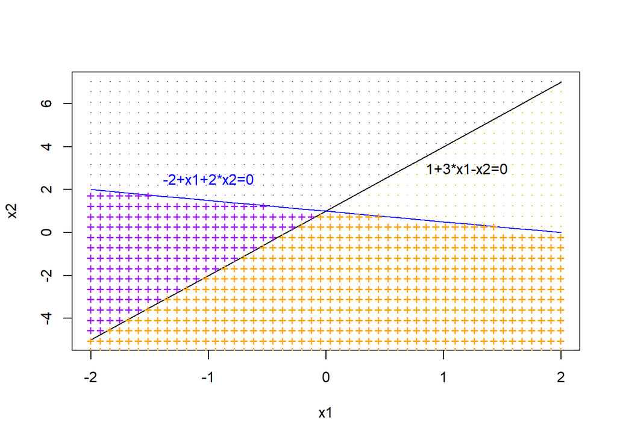

```r
x1 <- seq(-2,2,0.2)
x2a <- 3*x1+1
x2b <- -0.5*x1+1
plot(x1, x2a, type = 'l', ylab = 'x2')
lines(x1, x2b, col = 'blue')
for(i in seq(-2,2,length.out = 50)){
  p <- data.frame(rep(i,30),seq(-6,8,length.out = 30))
  points(p, col=ifelse(1+3*p[,1]-p[,2]>0,'orange','purple'),
         pch=ifelse(-2+p[,1]+2*p[,2]>0,'.','+'))
}
text(c(1.2), c(3), "1+3*x1-x2=0")
text(c(-1), c(2.5), "-2+x1+2*x2=0", col = 'blue')
```

The hyperplane $1+3 X_{1}-X_{2}=0$ is drawn in black line. The set of points for which $1+3 X_{1}-X_{2}>0$ is in orange, and the set of points for which $1+3 X_{1}-X_{2}<0$ is in purple.

The hyperplane $-2+X_{1}+2X_{2}=0$ is drawn in blue line. The set of points for which $-2+X_{1}+2 X_{2}>0$ is `.`, and the set of points for which $-2+X_{1}+2 X_{2}<0$ is `+`.

2. We have seen that in $p=2$ dimensions, a linear decision boundary takes the form $\beta_{0}+\beta_{1} X_{1}+\beta_{2} X_{2}=0$. We now investigate a non-linear decision boundary.

1. Sketch the curve
   $$\left(1+X_{1}\right)^{2}+\left(2-X_{2}\right)^{2}=4$$
2. On your sketch, indicate the set of points for which
   $$\left(1+X_{1}\right)^{2}+\left(2-X_{2}\right)^{2}>4$$
   as well as the set of points for which
   $$\left(1+X_{1}\right)^{2}+\left(2-X_{2}\right)^{2} \leq 4$$

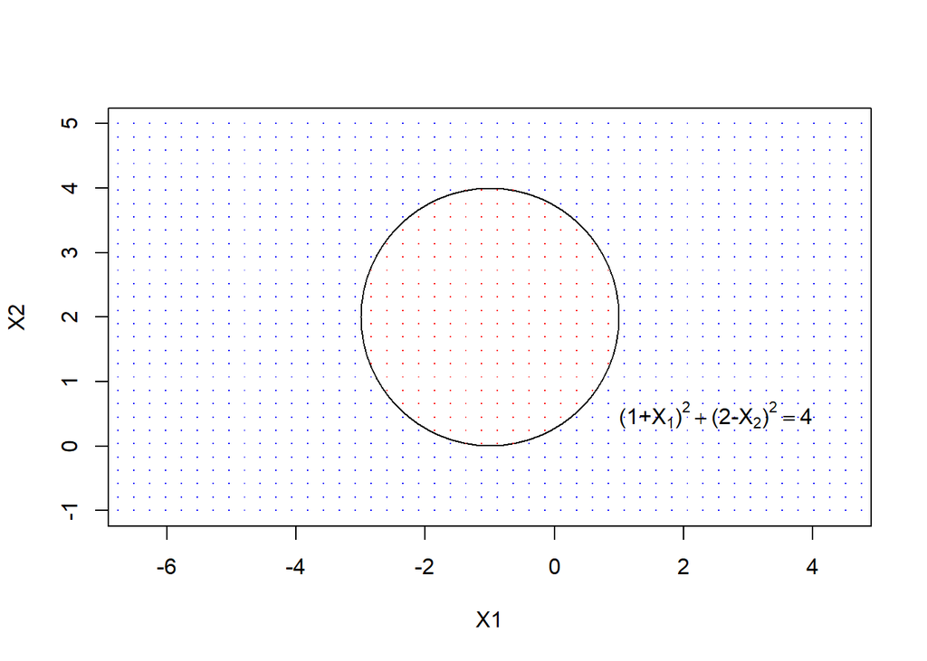

```r
plot(NA, NA, xlim = c(-4, 2), ylim = c(-1, 5), asp = 1, xlab = "X1", ylab = "X2")
symbols(c(-1), c(2), circles = c(2), add = TRUE, inches = FALSE)
for(i in seq(-7,5,length.out = 50)){
  p <- data.frame(rep(i,30),seq(-1,5,length.out = 30))
  points(p, col=ifelse((1+p[,1])^2+(2-p[,2])^2>4,'blue','red'), pch='.')
}
text(c(2.5), c(0.5), TeX('$(1+X_{1})^{2}+(2-X_{2})^{2} = 4$'))
```

The set of points for which $\left(1+X_{1}\right)^{2}+\left(2-X_{2}\right)^{2}>4$ is in blue, and the set of points for which $\left(1+X_{1}\right)^{2}+\left(2-X_{2}\right)^{2}\leq 4$ is in red.

3. Suppose that a classifier assigns an observation to the blue class if
   $$\left(1+X_{1}\right)^{2}+\left(2-X_{2}\right)^{2}>4$$
   and to the red class otherwise. To what class is the observation (0,0) classified? (-1,1)? (2,2)? (3,8)?

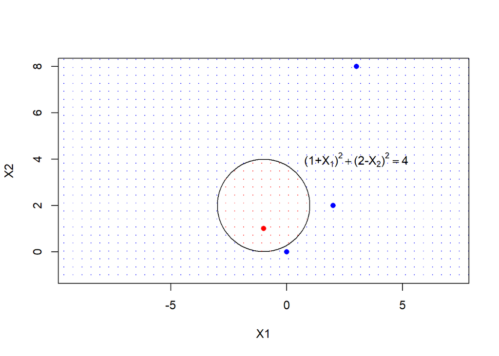

```r
plot(NA, NA, xlim = c(-4, 2), ylim = c(-1, 8), asp = 1, xlab = "X1", ylab = "X2")
symbols(c(-1), c(2), circles = c(2), add = TRUE, inches = FALSE)
for(i in seq(-10,9,length.out = 50)){
  p <- data.frame(rep(i,30),seq(-1,9,length.out = 30))
  points(p, col=ifelse((1+p[,1])^2+(2-p[,2])^2>4,'blue','red'), pch='.')
}
text(c(3), c(4), TeX('$(1+X_{1})^{2}+(2-X_{2})^{2} = 4$'))
points(0, 0, pch=16, col='blue')
points(-1, 1, pch=16, col='red')
points(2, 2, pch=16, col='blue')
points(3, 8, pch=16, col='blue')
```

The observation (-1,1) is classified to red class. The observations (0,0), (2,2) and (3,8) are classified to blue class.

4. Argue that while the decision boundary in (c) is not linear in terms of $X_{1}$ and $X_{2}$, it is linear in terms of $X_{1},\ X_{1}^{2},\ X_{2}$, and $X_{2}^{2}$

*Answer*. It is the linear combination of these terms
$$(1+X_{1})^{2}+(2-X_{2})^{2} > 4 \iff x_1^2+2x_1+x_2^2-4x_2>-1.$$

3. Here we explore the maximal margin classifier on a toy data set.

1. We are given $n=7$ observations in $p=2$ dimensions. For each observation, there is an associated class label. Sketch the observations.

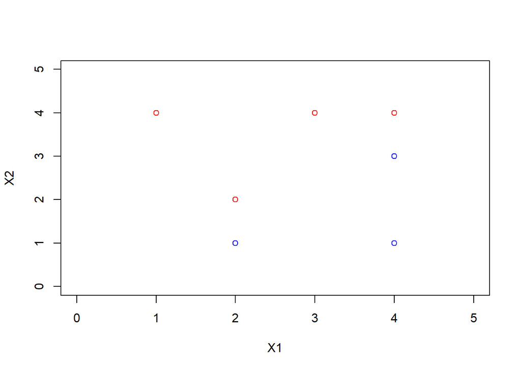

```r
dat <- data.frame(X1=c(3,2,4,1,2,4,4), X2=c(4,2,4,4,1,3,1), Y=c(rep('Red',4), rep('Blue',3)))
plot(dat[,c("X1", "X2")], xlim=c(0,5), ylim=c(0,5), col=dat[,c("Y")])
```

2. Sketch the optimal separating hyperplane, and provide the equation for this hyperplane (of the form (9.1)).

*Answer*. The maximal margin is between (2,1), (4,3) and (2,2), (4,4). The line will go through (2,1.5) and (4,3.5), that is,
$$0.5-X_1+X_2=0.$$

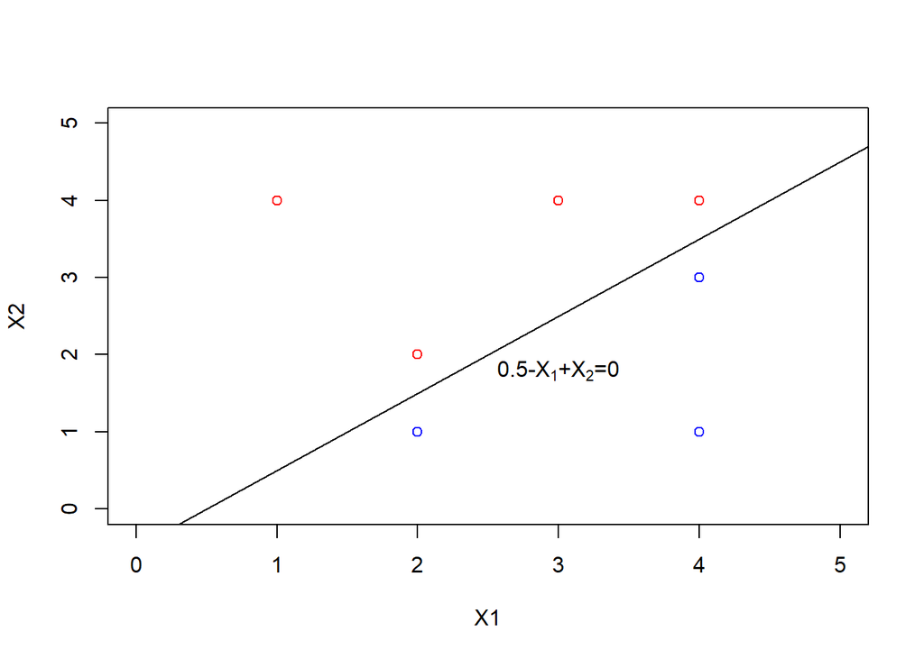

```r
plot(dat[,c("X1", "X2")], xlim=c(0,5), ylim=c(0,5), col=dat[,c("Y")])
abline(-0.5,1)
text(c(3),c(1.8),TeX('$0.5-X_{1}+X_{2}=0$'))
```

3. Describe the classification rule for the maximal margin classifier. It should be something along the lines of “Classify to Red if $\beta_{0}+\beta_{1} X_{1}+\beta_{2} X_{2}>0$, and classify to Blue otherwise.” Provide the values for $\beta_{0},\ \beta_{1}$, and $\beta_{2}$.

*Answer*. $\beta_0=0.5,\ \beta_1=-1,\ \beta_2=1$. Classify to Red if $0.5-X_1+X_2>0$, and classify to Blue otherwise.

4. On your sketch, indicate the margin for the maximal margin hyperplane.

```r
min(abs(0.5-dat$X1+dat$X2))  # Margin
```

```
## [1] 0.5
```

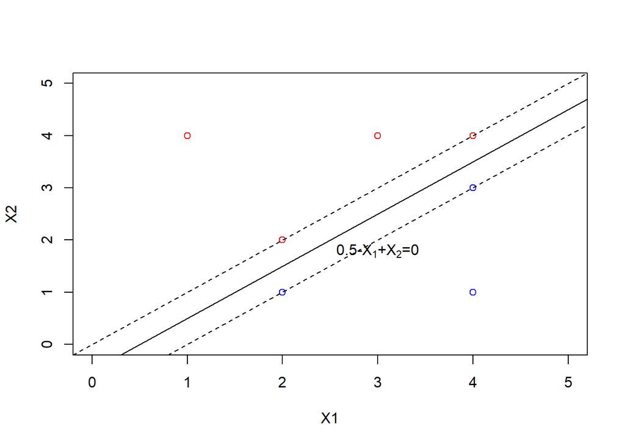

```r
plot(dat[,c("X1", "X2")], xlim=c(0,5), ylim=c(0,5), col=dat[,c("Y")])
abline(-0.5,1)
abline(-1,1,lty=2)
abline(0,1,lty=2)
text(c(3),c(1.8),TeX('$0.5-X_{1}+X_{2}=0$'))
```

5. Indicate the support vectors for the maximal margin classifier.

*Answer*. The support vectors are (2,1), (4,3) and (2,2), (4,4).

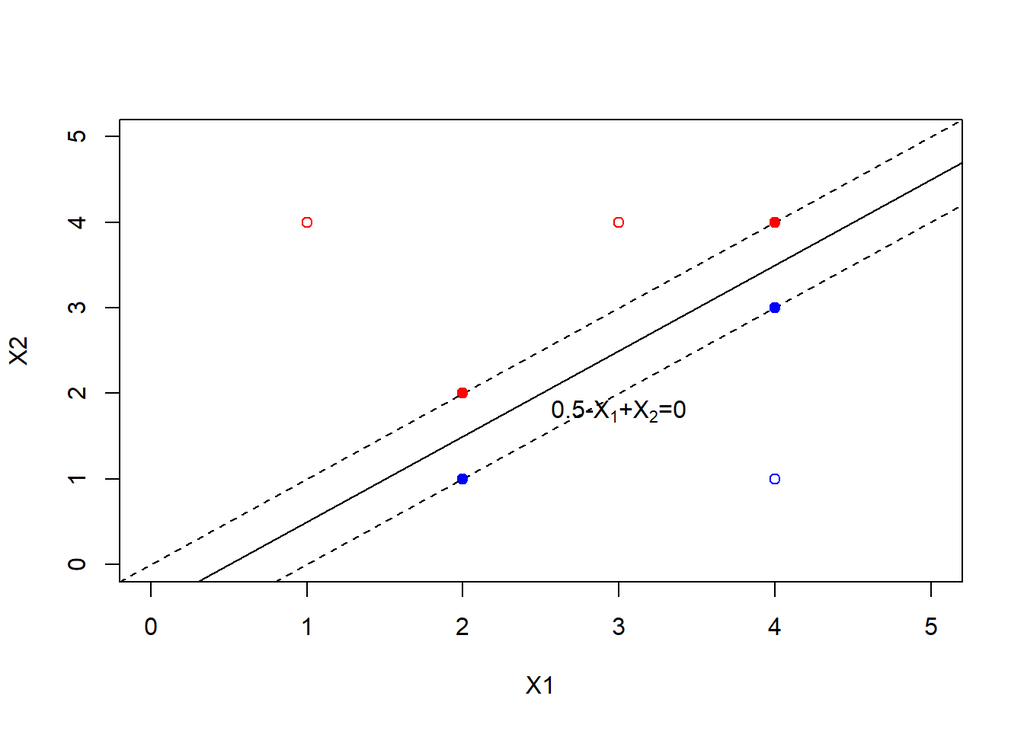

```r
plot(dat[,c("X1", "X2")], xlim=c(0,5), ylim=c(0,5), col=dat[,c("Y")])
abline(-0.5,1)
abline(-1,1,lty=2)
abline(0,1,lty=2)
points(dat[abs(0.5-dat$X1+dat$X2)==0.5,c("X1", "X2")], pch=16,
       col=dat[abs(0.5-dat$X1+dat$X2)==0.5,c("Y")])
text(c(3),c(1.8),TeX('$0.5-X_{1}+X_{2}=0$'))
```

6. Argue that a slight movement of the seventh observation would not affect the maximal margin hyperplane.

*Answer*. Because the seventh observation is not support vector, the slight movement will not affect the maximal margin hyperplane.

7. Sketch a hyperplane that is not the optimal separating hyperplane, and provide the equation for this hyperplane.

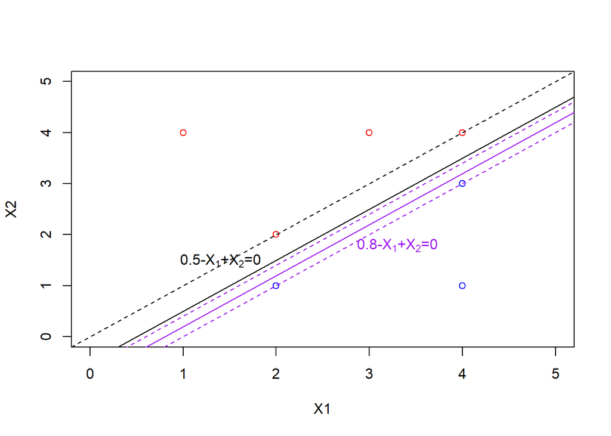

```r
plot(dat[,c("X1", "X2")], xlim=c(0,5), ylim=c(0,5), col=dat[,c("Y")])
abline(-0.5,1)
abline(-1,1,lty=2)
abline(0,1,lty=2)
abline(-0.8,1,col='purple')
mar <- min(abs(0.8-dat$X1+dat$X2))  # Margin
abline(-0.8+mar,1,lty=2,col='purple')
abline(-0.8-mar,1,lty=2,col='purple')
text(c(1.4),c(1.5),TeX('$0.5-X_{1}+X_{2}=0$'))
text(c(3.3),c(1.8),TeX('$0.8-X_{1}+X_{2}=0$'),col='purple')
```

8. Draw an additional observation on the plot so that the two classes are no longer separable by a hyperplane.

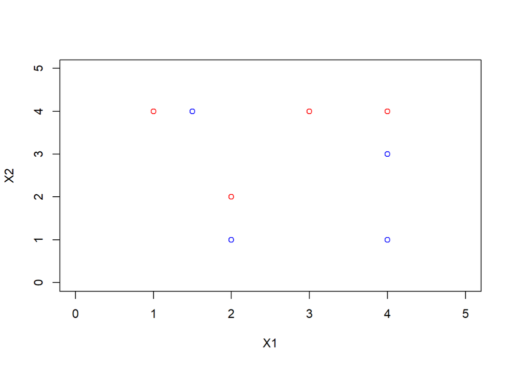

```r
plot(dat[,c("X1", "X2")], xlim=c(0,5), ylim=c(0,5), col=dat[,c("Y")])
points(1.5, 4, col='blue')
```